# Exercise Statistics for Natural Resources

Andrea Clemente Ureña

2025-05-22

## Numerical and Graphical Summary

```r
library(dplyr)
```

```r
library(ggplot2)
data(ChickWeight)
```

```r
# structure and summary
str(ChickWeight)
```

```
## Classes 'nfnGroupedData', 'nfGroupedData', 'groupedData' and 'data.frame':   578 obs. of  4 variables:
##  $ weight: num  42 51 59 64 76 93 106 125 149 171 ...
##  $ Time  : num  0 2 4 6 8 10 12 14 16 18 ...
##  $ Chick : Ord.factor w/ 50 levels "18"<"16"<"15"<..: 15 15 15 15 15 15 15 15 15 15 ...
##  $ Diet  : Factor w/ 4 levels "1","2","3","4": 1 1 1 1 1 1 1 1 1 1 ...
##  - attr(*, "formula")=Class 'formula'  language weight ~ Time | Chick
##   .. ..- attr(*, ".Environment")=<environment: R_EmptyEnv>
##  - attr(*, "outer")=Class 'formula'  language ~Diet
##   .. ..- attr(*, ".Environment")=<environment: R_EmptyEnv>
##  - attr(*, "labels")=List of 2
##   ..$ x: chr "Time"
##   ..$ y: chr "Body weight"
##  - attr(*, "units")=List of 2
##   ..$ x: chr "(days)"
##   ..$ y: chr "(gm)"
```

```r
summary(ChickWeight)
```

```
##      weight           Time           Chick     Diet
##  Min.   : 35.0   Min.   : 0.00   13     : 12   1:220
##  1st Qu.: 63.0   1st Qu.: 4.00   9      : 12   2:120
##  Median :103.0   Median :10.00   20     : 12   3:120
##  Mean   :121.8   Mean   :10.72   10     : 12   4:118
##  3rd Qu.:163.8   3rd Qu.:16.00   17     : 12
##  Max.   :373.0   Max.   :21.00   19     : 12
##                                  (Other):506
```

The `ChickWeight` dataset contains **578 observations** of **50 chicks**, each measured repeatedly over time.

- **`weight`**: *Chick body weight in grams*, ranging from **35g to 373g**.
- **`Time`**: *Number of days since birth*, ranging from **0 to 21 days**.
- **`Chick`**: *Ordered factor*. A unique identifier for each chick. Measurements are grouped by chick.
- **`Diet`**: *Factor with 4 levels*, indicating the experimental diet.

Some key insights from the dataset: - The **average chick weight** is approximately **122g**. - Most chicks were measured around **every 2 days**, starting from day 0 up to day 21. - **Diet groups are unbalanced** — Diet 1 has more observations than the others. - The dataset is ideal for *longitudinal modeling*, such as GLMMs or GAMs, because each chick has multiple measurements over time.

```r
ChickWeight %>%
  group_by(Diet) %>%
  summarise(
    Count = n(),
    Mean_Weight = mean(weight),
    SD_Weight = sd(weight),
    Max_Weight = max(weight),
    Min_Weight = min(weight)
  )
```

```
## # A tibble: 4 × 6
##   Diet  Count Mean_Weight SD_Weight Max_Weight Min_Weight
##   <fct> <int>       <dbl>     <dbl>      <dbl>      <dbl>
## 1 1       220        103.      56.7        305         35
## 2 2       120        123.      71.6        331         39
## 3 3       120        143.      86.5        373         39
## 4 4       118        135.      68.8        322         39
```

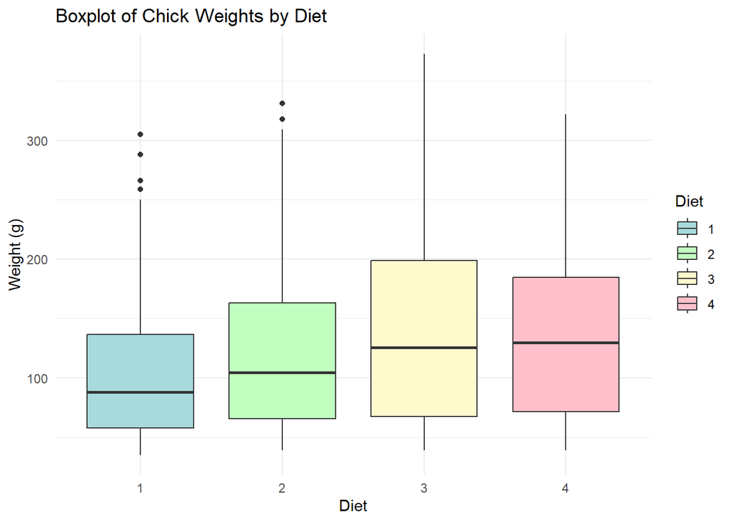

```r
ggplot(ChickWeight, aes(x = Diet, y = weight, fill = Diet)) +
  geom_boxplot() +
  scale_fill_manual(values = c("#A8DADC", "#C1FFC1", "#FFFACD", "#FFC0CB")) +
  labs(title = "Boxplot of Chick Weights by Diet",
       y = "Weight (g)", x = "Diet") +
  theme_minimal()
```

**Key Points:**

- **Diet 3** resulted in the heaviest chicks on average (**142.95g**) and had the highest maximum weight (**373g**), but also showed the **largest variation** in weights.
- **Diet 1** had the **lowest average weight** (**102.6g**) and the **highest number of observations**.
- The **minimum weight** was similar across all diets (~35–39g), but **maximum weights varied**, suggesting a strong effect of diet on growth.
- **Standard deviation** was highest for Diet 3, indicating that chick weights under this diet were more spread out.

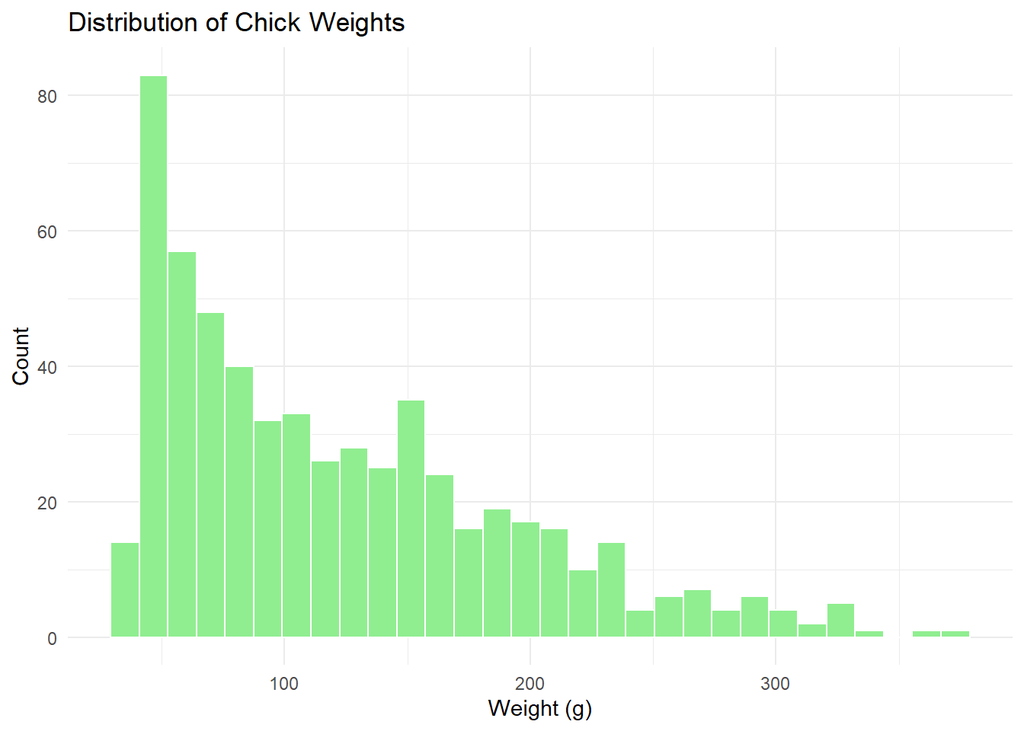

```r
ggplot(ChickWeight, aes(x = weight)) +
  geom_histogram(bins = 30, fill = "lightgreen", color = "white") +
  labs(title = "Distribution of Chick Weights",
       x = "Weight (g)", y = "Count") +
  theme_minimal()
```

The histogram of chick weights shows a **right-skewed distribution**:

- Most chicks have lower weights, especially in the early days.
- A few chicks reached much higher weights, creating a “long tail” on the right.
- This suggests the distribution is **not perfectly normal**, which may affect linear modeling assumptions.

```r
ChickWeight %>%
  group_by(Diet) %>%
  summarise(correlation = cor(Time, weight))
```

```
## # A tibble: 4 × 2
##   Diet  correlation
##   <fct>       <dbl>
## 1 1           0.816
## 2 2           0.818
## 3 3           0.898
## 4 4           0.952
```

**Key Points:**

- All diets show a **strong positive correlation** between age and weight, as expected — chicks grow over time.
- Diets **3 and 4** show the **strongest correlation**, suggesting a more consistent growth pattern across time for those diets.
- Diets **1 and 2** show slightly **weaker correlation**, possibly due to greater variability or outliers in chick growth.
- This supports the idea that *diet affects not just weight, but how predictably chicks grow over time*.

These correlations justify including **Time** as a predictor in subsequent models, and considering **Diet** as a potential modifier of the growth trajectory.

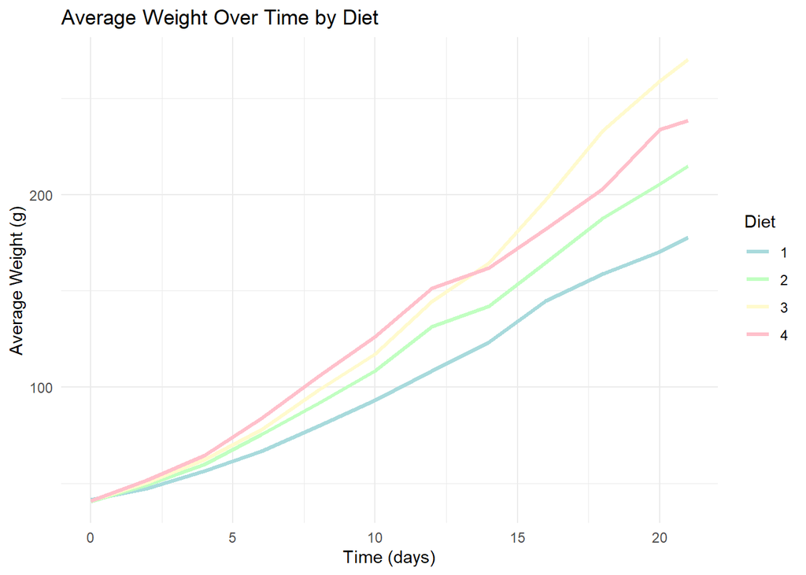

```r
ggplot(ChickWeight, aes(x = Time, y = weight, color = Diet)) +
  stat_summary(fun = mean, geom = "line", size = 1.2) +
  labs(title = "Average Weight Over Time by Diet",
       x = "Time (days)", y = "Average Weight (g)") +
  theme_minimal() +
  scale_color_manual(values = c("#A8DADC", "#C1FFC1", "#FFFACD", "#FFC0CB"))
```

**Key Points**

- **This line plot shows the average weight of chicks over time for each diet group.**
- **Diet 3** results in the **fastest and highest weight gain**, indicating a strong effect of this diet on growth.
- **Diet 4** also shows **steady improvement**, placing it second in growth performance.
- **Diet 2** and **Diet 1** show more **modest, linear growth patterns**, with **Diet 1** being the least effective in promoting weight gain.
- The **divergence in the lines over time** suggests increasing differences in weight outcomes between diets as chicks age.
- This plot helps visually confirm that **diet significantly impacts chick growth**, and motivates including **interaction terms or non-linear effects** in the modeling stage.

## Build a linear model using GLM using step and add function for variable selection

```r
# Null modelt
glm_null <- glm(weight ~ 1, data = ChickWeight)

# Full model
glm_full <- glm(weight ~ Time * Diet, data = ChickWeight)

# Stepwise model selection
glm_step <- step(glm_null,
                 scope = list(lower = glm_null, upper = glm_full),
                 direction = "both")
```

```
## Start:  AIC=6572.12
## weight ~ 1
##
##        Df Deviance    AIC
## + Time  1   872212 5876.8
## + Diet  3  2758693 6546.4
## <none>     2914556 6572.1
##
## Step:  AIC=5876.8
## weight ~ Time
##
##        Df Deviance    AIC
## + Diet  3   742336 5789.6
## <none>      872212 5876.8
## - Time  1  2914556 6572.1
##
## Step:  AIC=5789.61
## weight ~ Time + Diet
##
##             Df Deviance    AIC
## + Time:Diet  3   661532 5729.0
## <none>           742336 5789.6
## - Diet       3   872212 5876.8
## - Time       1  2758693 6546.4
##
## Step:  AIC=5729
## weight ~ Time + Diet + Time:Diet
##
##             Df Deviance    AIC
## <none>           661532 5729.0
## - Time:Diet  3   742336 5789.6
```

```r
summary(glm_step)
```

```
##
## Call:
## glm(formula = weight ~ Time + Diet + Time:Diet, data = ChickWeight)
##
## Coefficients:
##             Estimate Std. Error t value Pr(>|t|)
## (Intercept)  30.9310     4.2468   7.283 1.09e-12 ***
## Time          6.8418     0.3408  20.076  < 2e-16 ***
## Diet2        -2.2974     7.2672  -0.316  0.75202
## Diet3       -12.6807     7.2672  -1.745  0.08154 .
## Diet4        -0.1389     7.2865  -0.019  0.98480
## Time:Diet2    1.7673     0.5717   3.092  0.00209 **
## Time:Diet3    4.5811     0.5717   8.014 6.33e-15 ***
## Time:Diet4    2.8726     0.5781   4.969 8.92e-07 ***
## ---
## Signif. codes:  0 '***' 0.001 '**' 0.01 '*' 0.05 '.' 0.1 ' ' 1
##
## (Dispersion parameter for gaussian family taken to be 1160.583)
##
##     Null deviance: 2914556  on 577  degrees of freedom
## Residual deviance:  661532  on 570  degrees of freedom
## AIC: 5729
##
## Number of Fisher Scoring iterations: 2
```

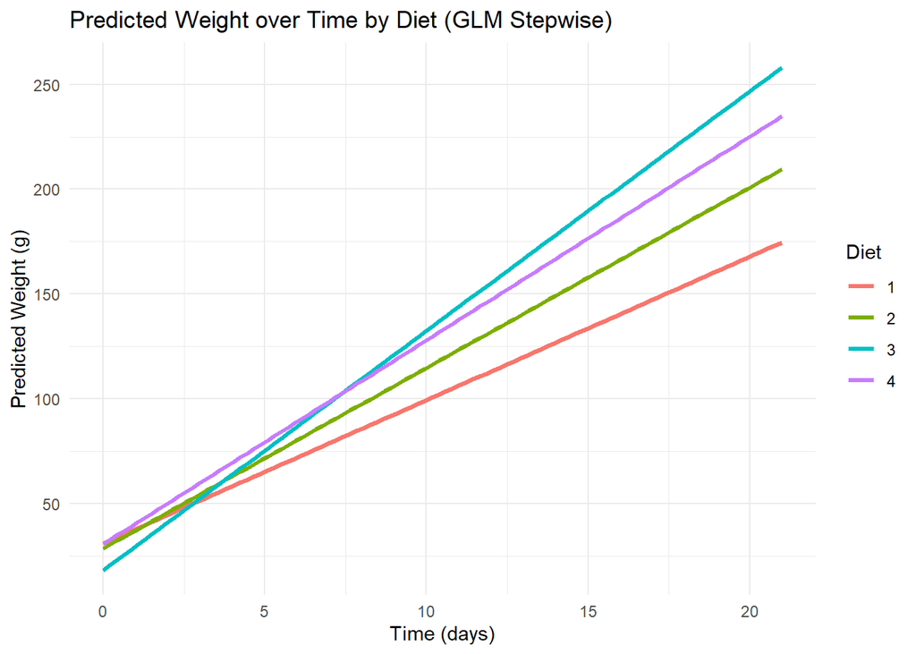

```r
newdata <- expand.grid(
  Time = seq(min(ChickWeight$Time), max(ChickWeight$Time), length.out = 100),
  Diet = levels(ChickWeight$Diet)
)

newdata$pred <- predict(glm_step, newdata = newdata)

# Plot predicted values
library(ggplot2)
ggplot(newdata, aes(x = Time, y = pred, color = Diet)) +
  geom_line(size = 1.2) +
  labs(title = "Predicted Weight over Time by Diet (GLM Stepwise)",
       x = "Time (days)", y = "Predicted Weight (g)") +
  theme_minimal()
```

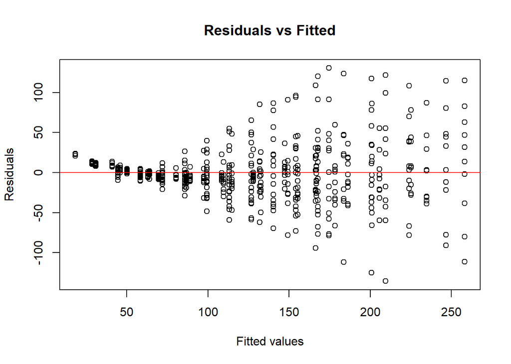

```r
# Residual plot
plot(glm_step$fitted.values, resid(glm_step),
     xlab = "Fitted values", ylab = "Residuals",
     main = "Residuals vs Fitted")
abline(h = 0, col = "red")
```

The final model is: *weight ~ Time + Diet + Time:Diet*

**Model fit:**

- The **AIC** decreased from **6572** (null model) to **5729**, indicating a substantially better fit as variables were added.
- The residual deviance dropped from **2,914,556** to **661,532**, showing the model explains a large portion of the variation in weight.

**Main effects:**

- **Time** has a strong positive effect on weight (**p < 0.001**), indicating that chicks gain weight as time increases.
- The effect of **Diet** alone is less clear: none of the individual Diet coefficients are statistically significant at the 5% level, though Diet 3 shows a marginal effect (**p = 0.081**).

**Interactions (Time:Diet):**

- There are significant interactions between **Time** and all diets except Diet 1 (the reference level).
- This suggests that the **rate of weight gain over time depends on the Diet**.
- In particular:
  - **Diet 3** shows the strongest interaction (**p < 0.001**), meaning chicks on Diet 3 gain weight faster over time.
  - **Diet 4** and **Diet 2** also show significant time interactions (**p < 0.01**), with moderate increases in growth rate.

**Residual analysis:**

- The residuals are centered around zero, as expected.
- However, there is a visible pattern: residuals are tightly clustered at lower fitted values and become more spread out at higher fitted values.
- This suggests **increasing variance**, a common issue in growth models, which could indicate **heteroscedasticity**.
- While the model still captures the main trends well, this pattern may violate the assumption of constant variance and could be explored further (e.g., with weighted regression or transformation).

## Build a GLMM model

```r
library(lme4)
glmm_model <- lmer(weight ~ Time * Diet + (1 | Chick), data = ChickWeight)
glmm_model
```

```
## Linear mixed model fit by REML ['lmerMod']
## Formula: weight ~ Time * Diet + (1 | Chick)
##    Data: ChickWeight
## REML criterion at convergence: 5466.905
## Random effects:
##  Groups   Name        Std.Dev.
##  Chick    (Intercept) 23.36
##  Residual             25.36
## Number of obs: 578, groups:  Chick, 50
## Fixed Effects:
## (Intercept)         Time        Diet2        Diet3        Diet4   Time:Diet2
##     31.5143       6.7115      -2.8807     -13.2640      -0.4016       1.8977
##  Time:Diet3   Time:Diet4
##      4.7114       2.9506
```

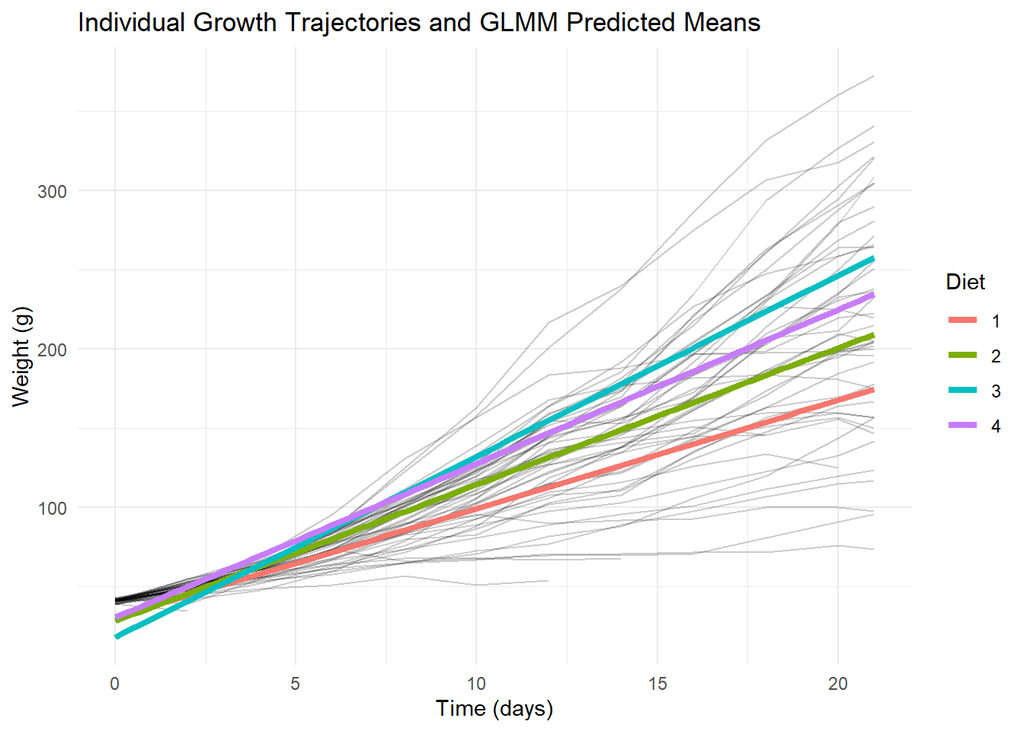

```r
ggplot() +
  geom_line(data = ChickWeight, aes(x = Time, y = weight, group = Chick), alpha = 0.2, color = "black") +
  geom_line(data = newdata, aes(x = Time, y = pred, color = Diet), size = 1.5) +
  labs(title = "Individual Growth Trajectories and GLMM Predicted Means",
       x = "Time (days)", y = "Weight (g)") +
  theme_minimal()
```

- The **individual lines** demonstrate substantial variability among chicks.
- The **average lines** show that Diet 3 again leads to the highest growth, while Diet 1 remains the slowest.
- This model captures both population-level trends and individual variability.

## Build a GAM model.

```r
library(mgcv)
gam_model <- gam(weight ~ s(Time, by=Diet) + Diet, data = ChickWeight)
summary(gam_model)
```

```
##
## Family: gaussian
## Link function: identity
##
## Formula:
## weight ~ s(Time, by = Diet) + Diet
##
## Parametric coefficients:
##             Estimate Std. Error t value Pr(>|t|)
## (Intercept)  104.276      2.265  46.044  < 2e-16 ***
## Diet2         16.610      3.812   4.358 1.56e-05 ***
## Diet3         36.325      3.812   9.530  < 2e-16 ***
## Diet4         30.636      3.831   7.996 7.25e-15 ***
## ---
## Signif. codes:  0 '***' 0.001 '**' 0.01 '*' 0.05 '.' 0.1 ' ' 1
##
## Approximate significance of smooth terms:
##                 edf Ref.df     F p-value
## s(Time):Diet1 1.891  2.350 177.9  <2e-16 ***
## s(Time):Diet2 1.613  1.995 181.2  <2e-16 ***
## s(Time):Diet3 2.294  2.846 228.0  <2e-16 ***
## s(Time):Diet4 1.051  1.100 406.9  <2e-16 ***
## ---
## Signif. codes:  0 '***' 0.001 '**' 0.01 '*' 0.05 '.' 0.1 ' ' 1
##
## R-sq.(adj) =  0.777   Deviance explained = 78.1%
## GCV = 1148.5  Scale est. = 1126.9    n = 578
```

```r
gam_model
```

```
##
## Family: gaussian
## Link function: identity
##
## Formula:
## weight ~ s(Time, by = Diet) + Diet
##
## Estimated degrees of freedom:
## 1.89 1.61 2.29 1.05  total = 10.85
##
## GCV score: 1148.49
```

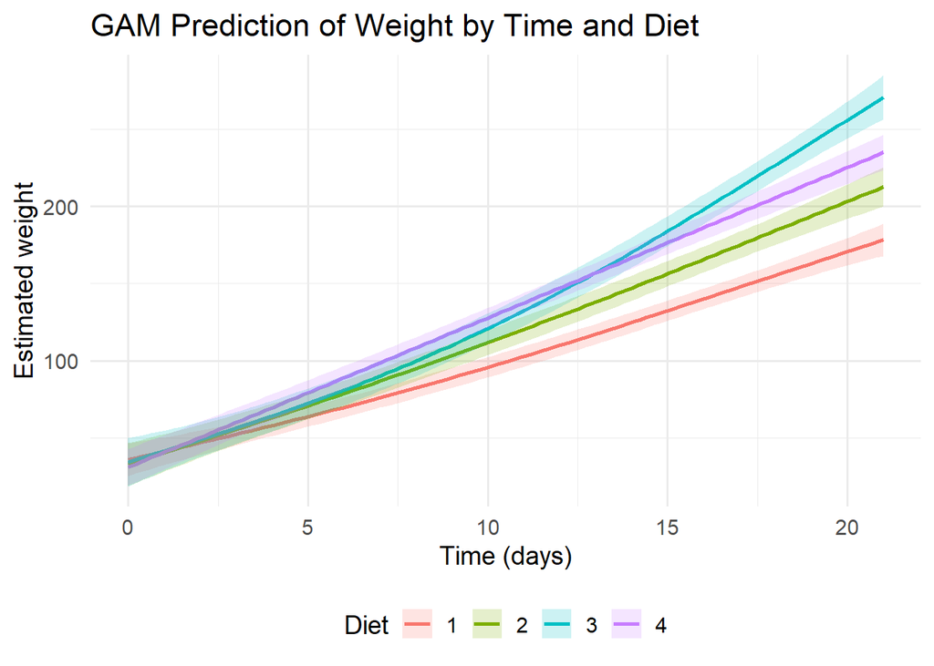

```r
newdata <- expand.grid(
  Time = seq(min(ChickWeight$Time), max(ChickWeight$Time), length.out = 100),
  Diet = levels(ChickWeight$Diet))
pred <- predict(gam_model, newdata = newdata, se.fit = TRUE)
newdata$fit <- pred$fit
newdata$se <- pred$se.fit
ggplot(newdata, aes(x = Time, y = fit, color = Diet, fill = Diet)) +
  geom_line(size = 1) +
  geom_ribbon(aes(ymin = fit - 2*se, ymax = fit + 2*se), alpha = 0.2, color = NA) +
  labs(title = "GAM Prediction of Weight by Time and Diet",
       x = "Time (days)", y = "Estimated weight") +
  theme_minimal(base_size = 14) +
  theme(legend.position = "bottom")
```

**The GAM analysis reveals** that the relationship between `Time` and `weight` is non-linear and varies by diet. Each diet is modeled with a separate smoothing function, allowing for more flexibility in capturing growth patterns.

This model is particularly effective in uncovering complex, non-linear growth dynamics that simpler models may miss.